# Data Set Selection and Initial Processing of Dataset GSE225356

BCB420 Assignment 1

Li Quan Soh

2024-02-06

# 1 Processing Data

#### Include necessary packages

## 1.1 Basic Data Exploration

#### Get the Geo description of my dataset

```r
data_set_geoid <- "GSE225356"
gse <- getGEO(data_set_geoid ,GSEMatrix=FALSE)
gse@header$summary
```

```
## [1] "Pharmacologic targeting of epigenetic protein complexes has shown significant in vitro responses in AML. Early clinical trials in MLL-rearranged leukemia indicate rather transient responses and development of resistance. In an effort to define functional dependencies of MLL-fusions in acute …
```

#### Information about the platform

| Platform Metadata | Info |
| --- | --- |
| Platform title | Illumina NovaSeq 6000 (Homo sapiens) |
| Submission data | Mar 02 2018 |
| Last update data | Nov 05 2018 |
| Organisms | Homo sapiens |
| Number of GEO datasets that use this technology | 12914 |
| Number of GEO samples that use this technology | 847368 |

#### Information about the data processing

```r
gse@gsms[[1]]@header$data_processing
```

```
## [1] "Sequence reads were trimmed for adaptor sequence/low-quality sequence using Trimmomatic v0.39"
## [2] "Trimmed sequence reads were aligned to the UCSC hg38 genome using STAR v2.7.10a."
## [3] "Read count extraction was performed using featureCounts v2.0.1"
## [4] "Normalization and differential gene expression analysis were performed using the DESeq2 R package"
## [5] "Assembly: hg38"
## [6] "Supplementary files format and content: tab-delimited matrix table (.txt)"
```

It is clear that the authors of the associated article gave very brief annotation of the data processing for this dataset. Nevertheless, it is clear enough to understand their overall pipeline for the dataset.

## 1.2 Verifying data and collating important annotation

#### Select the expression data file for downstream analysis

```r
# names of the supplementary files
suppl_files_names = getGEOSuppFiles(data_set_geoid, fetch_files = FALSE)
suppl_files_names$fname
```

```
## [1] "GSE225356_Comb_MI_DMSO_readscounts.txt.gz"
## [2] "GSE225356_DEG_RNAseq_MOLM-13_CombivsDMSO.txt.gz"
## [3] "GSE225356_DEG_RNAseq_MOLM-13_MIvsDMSO.txt.gz"
## [4] "GSE225356_RAW.tar"
```

```r
# select first supplementary file as our expression data file
data_filename <- suppl_files_names$fname[1]
```

The first supplementary file is selected as file 2 and 3 seems to be the result of the Differential Expressed Gene (DEG) Analysis. File 4 seems to be the raw file.

#### Download expression data file

```r
# set download directory for data file
download_dir <- file.path(getwd())

suppl_files = getGEOSuppFiles(data_set_geoid,
                        baseDir = download_dir,
                        fetch_files = TRUE)
```

#### Read in and verify data

```r
# Read in the data
rnaseq_df <- read.table(
  file.path(download_dir, data_set_geoid, data_filename),
  header = TRUE,
  check.names = TRUE)

# dimension of the rnaseq dataframe
dim(rnaseq_df)
```

```
## [1] 38557    12
```

```r
# how many samples did the the dataset have?
length(gse@gsms)
```

```
## [1] 11
```

The dataframe has 38557 rows, which corresponds to 38557 genes. In a typical RNAseq, there should be approximately 20000s to 30000s genes. Thus, we conclude that our data file has sufficient gene coverage. There are 12 columns (one of which is the Gene Name). This match the number of samples in the dataset: 11.

#### Presentation of our selected expression data “rnaseq_df”

```r
kable(rnaseq_df[1:5,1:4], format = "html")
```

| Gene | Com1 | Com2 | Com4 |
| --- | --- | --- | --- |
| DDX11L1 | 6 | 2 | 1 |
| WASH7P | 891 | 442 | 609 |
| MIR6859-1 | 35 | 27 | 29 |
| MIR1302-2HG | 0 | 0 | 0 |
| MIR1302-2 | 0 | 0 | 0 |

#### Further investigation of the annotations in our dataset

```r
colnames(rnaseq_df)[1:11]
```

```
##  [1] "Gene" "Com1" "Com2" "Com4" "D1"   "D2"   "D3"   "D4"   "MI1"  "MI2"
## [11] "MI3"
```

```r
gse@gsms[[1]]@header$characteristics_ch1
```

```
## [1] "cell line: MOLM-13"                "cell type: acute myeloid leukemia"
## [3] "treatment: DMSO control"           "time: 72h"
```

- Com is an abbreviation for “combination”, denoting treatment of MI-503 (menin inhibitor) and PR-957 (selective immunoproteosome inhibitor).
- D is an abbreviation for the DMSO control.
- MI is an abbreviation for the menin inhibitor treatment.

Each sample has annotation about the cell line, cell type, treatment type, and time of observation.

#### Collating the important annotations

```r
# Collect all the crucial sample annotations into one dataframe
samples_info <- do.call(rbind,
                        lapply(gse@gsms,
                               FUN = function(x){
                                 c(x@header$title,
                                   x@header$characteristics_ch1)
                               }
                              ))

# Clean up sample description
colnames(samples_info) <- c("Title", "Cell Line", "Cell Type", "Treatment",
                            "Observation Time")
samples_info[,'Cell Line'] <- gsub(samples_info[,'Cell Line'],
                                   pattern = "cell line: ",
                                   replacement = "")
samples_info[,'Cell Type'] <- gsub(samples_info[,'Cell Type'],
                                   pattern = "cell type: ",
                                   replacement = "")
samples_info[,'Treatment'] <- gsub(samples_info[,'Treatment'],
                                   pattern = "treatment: ",
                                   replacement = "")
samples_info[,'Observation Time'] <- gsub(samples_info[,'Observation Time'],
                                   pattern = "time: ",
                                   replacement = "")

kable(samples_info[1:7,], format = "html")
```

|  | Title | Cell Line | Cell Type | Treatment | Observation Time |
| --- | --- | --- | --- | --- | --- |
| GSM7047223 | MOLM-13, DMSO, rep 1 | MOLM-13 | acute myeloid leukemia | DMSO control | 72h |
| GSM7047224 | MOLM-13, DMSO, rep 2 | MOLM-13 | acute myeloid leukemia | DMSO control | 72h |
| GSM7047225 | MOLM-13, DMSO, rep 3 | MOLM-13 | acute myeloid leukemia | DMSO control | 72h |
| GSM7047226 | MOLM-13, DMSO, rep 4 | MOLM-13 | acute myeloid leukemia | DMSO control | 72h |
| GSM7047227 | MOLM-13, MI-503, rep 1 | MOLM-13 | acute myeloid leukemia | MI-503 | 72h |
| GSM7047228 | MOLM-13, MI-503, rep 2 | MOLM-13 | acute myeloid leukemia | MI-503 | 72h |
| GSM7047229 | MOLM-13, MI-503, rep 3 | MOLM-13 | acute myeloid leukemia | MI-503 | 72h |

# 2 Data Cleaning and Normalization

## 2.1 Mapping to HUGO symbols

```r
#checking if any redundant gene rows
length(unique(rnaseq_df[,1])) - length(rnaseq_df[,1])
```

```
## [1] 0
```

```r
#check to see the percentage of gene rows that have "LOC" (symbols not available at the time of publication)
length(grep("LOC",rnaseq_df[,1])) / length(rnaseq_df[,1]) * 100
```

```
## [1] 29.31245
```

This suggests that there are no duplicate genes in the RNASeq dataframe. The gene rows are already using HGNC symbols. Upon further inspection, ~29% of the rows have “LOC” prefix (these genes do not have HGNC symbols associated with them at the time of publication). We will map the geneIDs with “LOC” prefix to HGNC symbol with *clusterProfiler* (beginner and akrun 2023) to see if there are any updated HGNC symbols for those genes. *org.Hs.eg.db* (M 2019) is the most suitable for mapping Entrez ID to HGNC symbols for human gene data.

```r
# Create a column 'hgnc_symbols' with only gene symbols OR NA
library(tibble)
library(org.Hs.eg.db)
hgnc_symbol <- c()

# mapping LOC entrezID (modified code by [@entrezIDmapping])
for (gene_name in rnaseq_df[,1]){
  if (grepl("LOC", gene_name)){
    geneID <- gsub(gene_name,
                   pattern = "^LOC",
                   replacement = "")
    symb <- try(suppressMessages(clusterProfiler::bitr(geneID,
                 fromType = "ENTREZID",
                 toType = "SYMBOL",
                 OrgDb = org.Hs.eg.db))[1,2], silent = TRUE)
    if("try-error" %in% class(symb)){
      symb <- NA
    }
  } else {
    symb <- gene_name
  }
  hgnc_symbol <- c(hgnc_symbol, symb)
}
```

#### Create a copy of the RNASeq dataframe with updated HGNC symbols

```r
#bind the hgnc_symbol object to rnaseq_df_HGNC
rnaseq_df_HGNC <- data.frame(rnaseq_df)
rnaseq_df_HGNC["hgnc_symbol"] <- hgnc_symbol
rnaseq_df_HGNC <- rnaseq_df_HGNC[,c(1,13,2:12)]

#save the dataframe
save(rnaseq_df_HGNC,file="rnaseq_df_HGNC.Rda")
```

```r
# visualize the dataframe
load("rnaseq_df_HGNC.Rda")
kable(rnaseq_df_HGNC[1:5,1:4], format = "html")
```

| Gene | hgnc_symbol | Com1 | Com2 |
| --- | --- | --- | --- |
| DDX11L1 | DDX11L1 | 6 | 2 |
| WASH7P | WASH7P | 891 | 442 |
| MIR6859-1 | MIR6859-1 | 35 | 27 |
| MIR1302-2HG | MIR1302-2HG | 0 | 0 |
| MIR1302-2 | MIR1302-2 | 0 | 0 |

#### Statistics of the RNASeq dataframe with updated HGNC symbols

```r
#how many gene rows have no available symbols
(symb_NA <- sum(is.na(rnaseq_df_HGNC["hgnc_symbol"])))
```

```
## [1] 1690
```

```r
# how many gene rows have "LOC" in their symbols (appear in GeneCards, but not HGNC)
(symb_LOC <- sum(grepl("LOC", unlist(rnaseq_df_HGNC["hgnc_symbol"]))))
```

```
## [1] 8689
```

```r
# percentage of genes that have no proper hgnc symbols and "LOC" prefixes
(symb_NA + symb_LOC)/nrow(rnaseq_df_HGNC)*100
```

```
## [1] 26.91859
```

```r
# percentage of genes that have no available symbols
(symb_NA)/nrow(rnaseq_df_HGNC)*100
```

```
## [1] 4.383121
```

After mapping and verification, it appears only 1690 genes have no available gene symbols, and 8689 gene have “LOC” prefixes. Initially, we had 29.3% of the genes with no gene symbols. After mapping, only 4.4% of the genes have no available symbols, and a combined 26.9% of the genes with no available symbols or symbols having “LOC” prefixes.

## 2.2 Filtering & Normalization

#### Filtering Data: Removing Low Counts

```r
library(limma)
```

```r
library(edgeR)

# figuring out the groups of the comparison I'm trying to make
samples_info_dt <- data.table::data.table(samples_info)
samples_info_dt[, .(count = .N), by = samples_info_dt$Treatment]
```

| samples_info_dt | count |
| --- | --- |
| DMSO control | 4 |
| MI-503 | 4 |
| MI-503 + PR-957 | 3 |

```r
# minimal number of samples
min_samples <- 3
data_matrix <- as.matrix(rnaseq_df_HGNC[,-c(1,2)])
rownames(data_matrix) <- unlist(rnaseq_df_HGNC["Gene"])

# removing low counts
filtered = rowSums(cpm(data_matrix) > 1) > min_samples
filtered_data_matrix = data_matrix[filtered,]

# verifying the filtered_data_matrix have appropriate dimensions and row names to associate the row to the filtered genes
dim(filtered_data_matrix)
```

```
## [1] 12666    11
```

```r
head(rownames(filtered_data_matrix))
```

```
## [1] "WASH7P"       "LOC100996442" "WASH9P"       "LOC100133331" "LOC100288069"
## [6] "LINC01409"
```

#### Comparing the data pre- & post- filter

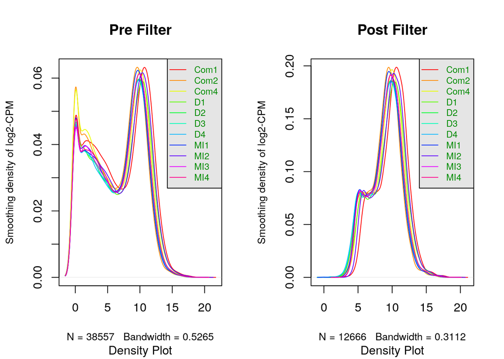

```r
par(mfrow = c(1, 2))

#Pre-filter
data2plot <- log2(data_matrix)
counts_density <- apply(log2(data_matrix), 2, density)
#calculate the limits across all the samples
xlim <- 0; ylim <- 0
for (i in 1:length(counts_density)) {
xlim <- range(c(xlim, counts_density[[i]]$x));
ylim <- range(c(ylim, counts_density[[i]]$y))
}
cols <- rainbow(length(counts_density))
ltys <- rep(1, length(counts_density))
#plot the first density plot to initialize the plot
plot(counts_density[[1]], xlim=xlim, ylim=ylim, type="n",
ylab="Smoothing density of log2-CPM",
main="Pre Filter", sub="Density Plot", cex.lab = 0.85)
#plot each line
for (i in 1:length(counts_density))
lines(counts_density[[i]], col=cols[i], lty=ltys[i])
#create legend
legend("topright", colnames(data2plot),
col=cols, lty=ltys, cex=0.75,
border ="blue", text.col = "green4",
merge = TRUE, bg = "gray90")

#Post-filter
filtered_data2plot <- log2(filtered_data_matrix)
filtered_counts_density <- apply(log2(filtered_data_matrix), 2, density)
#calculate the limits across all the samples
xlim <- 0; ylim <- 0
for (i in 1:length(filtered_counts_density)) {
xlim <- range(c(xlim, filtered_counts_density[[i]]$x));
ylim <- range(c(ylim, filtered_counts_density[[i]]$y))
}
cols <- rainbow(length(filtered_counts_density))
ltys <- rep(1, length(filtered_counts_density))
#plot the first density plot to initialize the plot
plot(filtered_counts_density[[1]], xlim=xlim, ylim=ylim, type="n",
ylab="Smoothing density of log2-CPM",
main="Post Filter", sub="Density Plot", cex.lab = 0.85)
#plot each line
for (i in 1:length(filtered_counts_density))
lines(filtered_counts_density[[i]], col=cols[i], lty=ltys[i])
#create legend
legend("topright", colnames(filtered_data2plot),
col=cols, lty=ltys, cex=0.75,
border ="blue", text.col = "green4",
merge = TRUE, bg = "gray90")
```

From the above graphs, it is evident that there were many genes with low-count that contribute to the noise of my data. Removing them makes the samples to be follow similar curve to each other. However, only 32.8500661% of the genes remained after removing the noises, as previously noted.

#### Applying TMM to our dataset

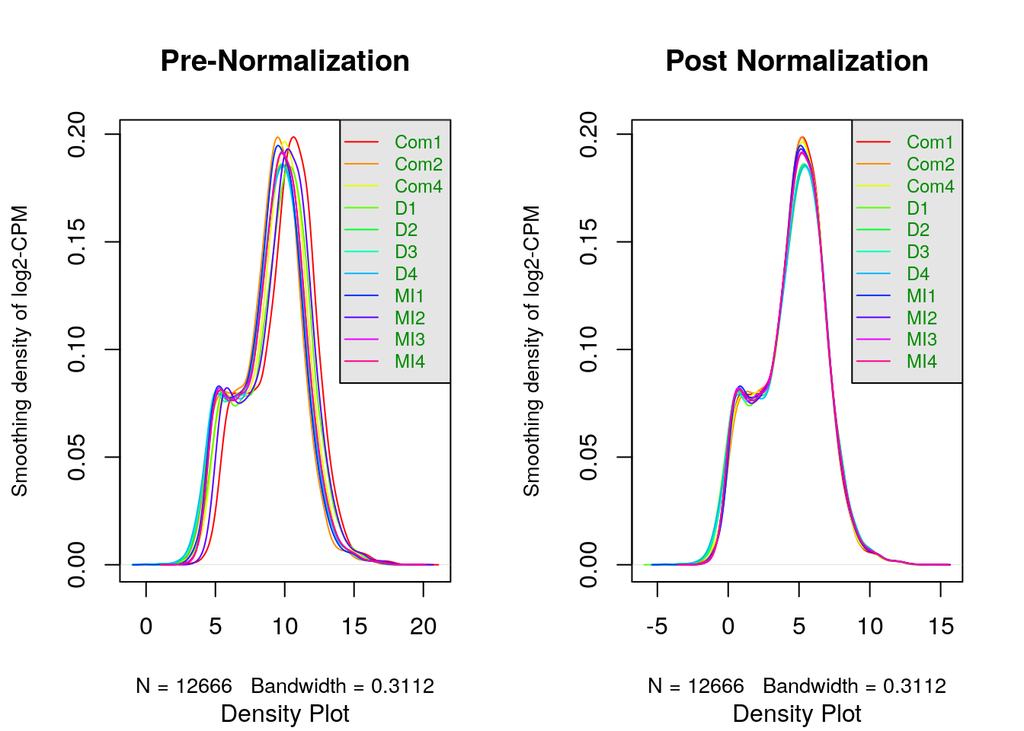

```r
# Create an edgeR container for RNASeq count data and calculate the normalization factors.
edgeR_container = DGEList(counts=filtered_data_matrix, group=samples_info_dt$Treatment)
edgeR_container = calcNormFactors(edgeR_container)

# Visualize pre- & post- normalization
# get the normalized count
normalized_counts <- cpm(edgeR_container)

par(mfrow = c(1, 2))
# pre-normalized
filtered_data2plot <- log2(filtered_data_matrix)
filtered_counts_density <- apply(log2(filtered_data_matrix), 2, density)
#calculate the limits across all the samples
xlim <- 0; ylim <- 0
for (i in 1:length(filtered_counts_density)) {
xlim <- range(c(xlim, filtered_counts_density[[i]]$x));
ylim <- range(c(ylim, filtered_counts_density[[i]]$y))
}
cols <- rainbow(length(filtered_counts_density))
ltys <- rep(1, length(filtered_counts_density))
#plot the first density plot to initialize the plot
plot(filtered_counts_density[[1]], xlim=xlim, ylim=ylim, type="n",
ylab="Smoothing density of log2-CPM",
main="Pre-Normalization", sub="Density Plot", cex.lab = 0.85)
#plot each line
for (i in 1:length(filtered_counts_density))
lines(filtered_counts_density[[i]], col=cols[i], lty=ltys[i])
#create legend
legend("topright", colnames(filtered_data2plot),
col=cols, lty=ltys, cex=0.75,
border ="blue", text.col = "green4",
merge = TRUE, bg = "gray90")

# post-normalized
normalized_data2plot <- log2(normalized_counts)
normalized_counts_density <- apply(log2(normalized_counts), 2, density)
#calculate the limits across all the samples
xlim <- 0; ylim <- 0
for (i in 1:length(normalized_counts_density)) {
xlim <- range(c(xlim, normalized_counts_density[[i]]$x));
ylim <- range(c(ylim, normalized_counts_density[[i]]$y))
}
cols <- rainbow(length(normalized_counts_density))
ltys <- rep(1, length(normalized_counts_density))
#plot the first density plot to initialize the plot
plot(normalized_counts_density[[1]], xlim=xlim, ylim=ylim, type="n",
ylab="Smoothing density of log2-CPM",
main="Post Normalization", sub="Density Plot", cex.lab = 0.85)
#plot each line
for (i in 1:length(normalized_counts_density))
lines(normalized_counts_density[[i]], col=cols[i], lty=ltys[i])
#create legend
legend("topright", colnames(normalized_data2plot),
col=cols, lty=ltys, cex=0.75,
border ="blue", text.col = "green4",
merge = TRUE, bg = "gray90")
```

It is evident that the sampling distributions have become even more similar after normalization, while retaining the same number of genes (N = 12666).

#### Visualizing the distribution of the data via Boxplot

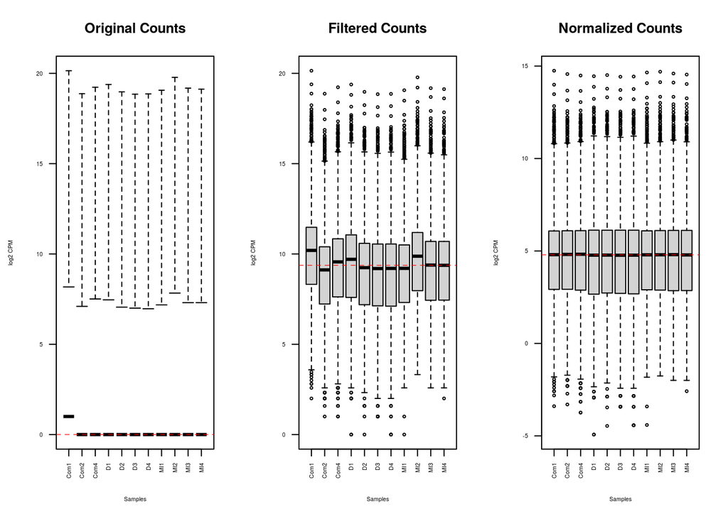

```r
#Boxplot comparing original vs filtered & normalized dataset
par(mfrow = c(1, 3))

# Original Dataset
boxplot(data2plot, xlab = "Samples", ylab = "log2 CPM",
las = 2, cex = 0.5, cex.lab = 0.5,
cex.axis = 0.5, main = "Original Counts")
#draw the median on each box plot
abline(h = median(apply(data2plot, 2, median)),
col = "red", lwd = 0.6, lty = "dashed")

# Filtered Dataset
boxplot(filtered_data2plot, xlab = "Samples", ylab = "log2 CPM",
las = 2, cex = 0.5, cex.lab = 0.5,
cex.axis = 0.5, main = "Filtered Counts")
#draw the median on each box plot
abline(h = median(apply(filtered_data2plot, 2, median)),
col = "red", lwd = 0.6, lty = "dashed")

# Filtered and Normalized Dataset
boxplot(normalized_data2plot, xlab = "Samples", ylab = "log2 CPM",
las = 2, cex = 0.5, cex.lab = 0.5,
cex.axis = 0.5, main = "Normalized Counts")
#draw the median on each box plot
abline(h = median(apply(normalized_data2plot, 2, median)),
col = "red", lwd = 0.6, lty = "dashed")
```

The original datasets have many genes that have 0 read counts, skewing the data towards 0. After filtering, the dataset’s mean has shifted to log2 CPM = 10. However, the samples not very uniformed. After normalization, the dataset’s mean has shifted to log2 CPM = 5 and the samples are fairly uniformed

#### Visualizing the distirbution of the data via MDS plot

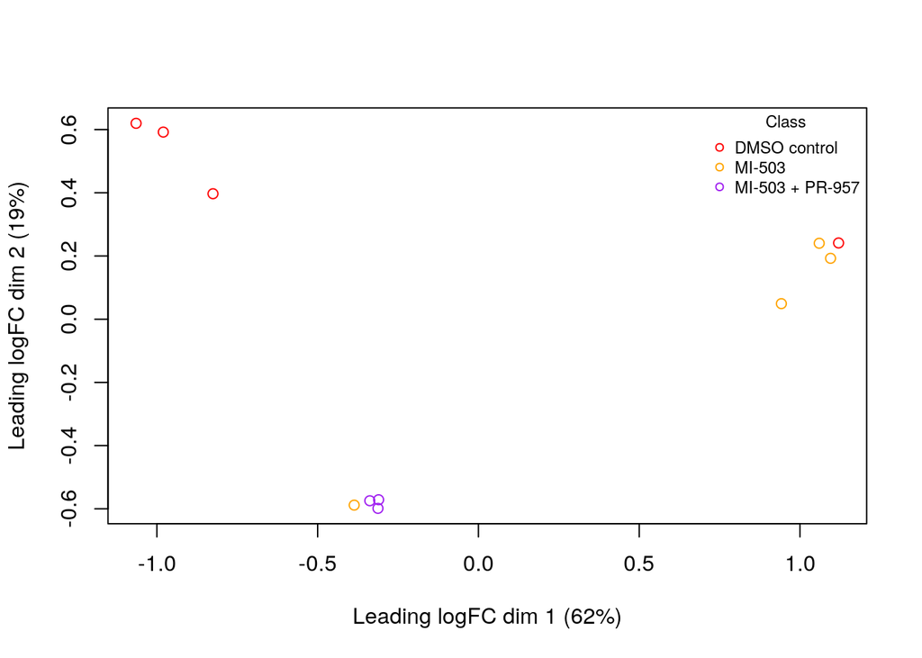

```r
# MDS plot to inspect sample separation
limma::plotMDS(edgeR_container, labels=NULL,pch=1,
col = c("red","orange","purple","brown")[factor(samples_info_dt$Treatment)])
legend("topright",
legend=levels(factor(samples_info_dt$Treatment)),
pch=c(1), col=c("red","orange","purple","brown"),title="Class",
bty = 'n', cex = 0.75)
```

#### Dispersion

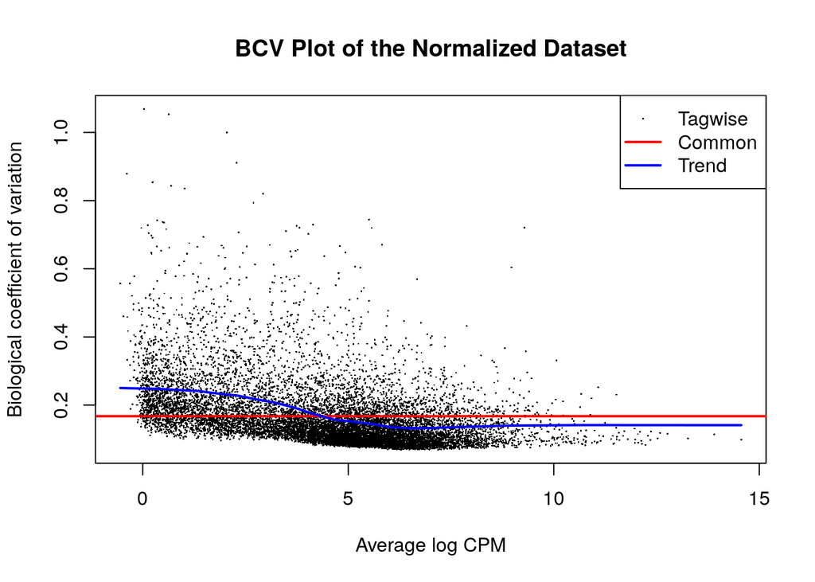

```r
# Estimating dispersion in the data
model_design <- model.matrix(~samples_info_dt$Treatment)
edgeR_container <- estimateDisp( edgeR_container, model_design)

# BCV plot to visualize dispersion
plotBCV(edgeR_container,col.tagwise = "black",col.common = "red",
        main = "BCV Plot of the Normalized Dataset")
```

Common dispersion is the mean dispersion across all genes. Trend dispersion is mean dispersion across all genes with similar CPM. This plot suggests that the common dispersion and trend dispersion is relatively similar to each other, hovering around the BCV value of approximately 0.15. A BCV of .15 for human samples suggest that the variation in my data isn’t too big. Perhaps there will not be many differentially expressed genes in downstream DEG analysis.

#### Visualizing the mean-variance relationship

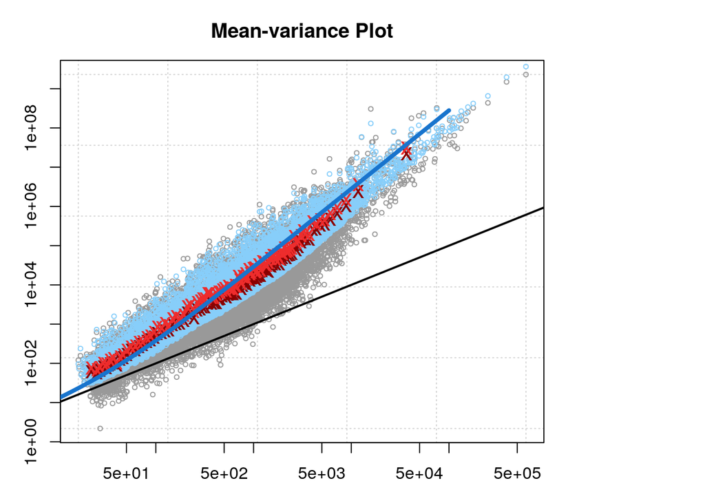

```r
# For proper formatting
par(mar = c(3, 3, 3, 8))

# Plotting the mean-variance relationship
plotMeanVar(edgeR_container, show.raw.vars = TRUE, show.tagwise.vars=TRUE,
            show.ave.raw.vars = TRUE,
            NBline = TRUE,
            show.binned.common.disp.vars = TRUE,
            main = "Mean-variance Plot")
```

#### Combining replicates for each treatment group

```r
# define grouping
group <- c("MI-503 + PR-957", "DMSO control", "MI-503")
rep_num <- c(3, 4, 4)
grouped_df <- c()

# combine replicates for each group
counter <- 1
for (i in seq_along(rep_num)) {
  grouped_df <- cbind(grouped_df, rowMeans(normalized_data2plot[, counter:(counter+rep_num[i]-1)]))
  counter <- counter + rep_num[i]
}
colnames(grouped_df) <- group

# visualize
kable(grouped_df[1:5,1:3], format = "html")
```

|  | MI-503 + PR-957 | DMSO control | MI-503 |
| --- | --- | --- | --- |
| WASH7P | 4.467261 | 4.1525564 | 4.2012743 |
| LOC100996442 | 1.938699 | 0.0514897 | 0.7109804 |
| WASH9P | 3.800661 | 3.4656327 | 3.5004091 |
| LOC100133331 | 1.486033 | 1.2228368 | 1.0891951 |
| LOC100288069 | 2.238413 | 1.5529672 | 1.5042338 |

#### Exporting the filtered & normalized dataset

```r
# Writing out the filtered & normalized dataset
write.table(normalized_counts,
            file.path(getwd(),data_set_geoid,
                      paste(data_set_geoid,
                            "filtered_normalized_counts.txt",
                            sep="_")),
            quote = FALSE, sep="\t", row.names = TRUE)
```

# 3 Interpretations & Conclusion

#### Key Interpretations

1. Why is the dataset of interest to you?
- I want to detect genes of interest that are associated with the oncogenic transcriptional networks in AML. Further downstream differential gene analysis may elucidate key genes that can be pharmacologically targeted for treatment of AML. In particular, I want to verify the genes (eg PSMB8, BASP1) mentioned in the associated paper (Tubı́o-Santamarı́a et al. 2023) indeed good targets for AML treatments.
2. What are the control and test conditions of the dataset?
- Link: Further investigation of the annotations in our dataset
3. How many samples in each of the conditions of your dataset?
- Link: [Filtering Data: Removing Low Count]
4. Were there expression values that were not unique for specific genes? How did you handle these?
- Link: 2.1 Mapping to HUGO symbols
5. Were there expression values that could not be mapped to current HUGO symbols?
- Link: 2.1 Mapping to HUGO symbols
6. Were there any outliers in your dataset? How were they handled in the originating paper? How many outliers were removed?
- Link: Filtering Data: Removing Low Counts
7. How did you handle replicates?
- Link: Combining replicates for each treatment group
8. What is the final coverage of your dataset?
- Initially, the coverage is 38557 genes. Read in and verify data
- After filtering and normalization, the final coverage is 12666 genes. Applying TMM to our dataset

#### Conclusion

In this project, I have meticulously processed and analyzed the gene expression dataset **GSE225356**. I began by exploring the dataset’s metadata, examining the platform information and data processing steps.

My analysis involved several critical steps, including filtering out genes with low counts, mapping gene IDs to HUGO symbols, and normalizing the data to account for technical biases. I meticulously inspected the data before and after filtering and normalization, ensuring that the normalization procedures effectively reduced variation and improved data quality.

Furthermore, I conducted exploratory data analysis, visualizing the distribution of gene expression values and examining sample relationships through MDS plots. I also estimated common and tagwise dispersion in the data, and plotted the mean-variance relationship to ensure that the data conformed to edgeR protocol.

Through these initial processing, I have prepared a filtered and normalized dataset ready for downstream analysis.

beginner, and akrun. 2023. “How to Convert Entrez Ids in a Large List into Gene Symbols and Replace Entrez Ids in List in r?” https://stackoverflow.com/questions/70975616/how-to-convert-entrez-ids-in-a-large-list-into-gene-symbols-and-replace-entrez-i.

M, Carlson. 2019. *Org.hs.eg.db: Genome Wide Annotation for Human*. 10.18129/B9.bioc.org.Hs.eg.db.

Tubı́o-Santamarı́a, Nuria, Ashok Kumar Jayavelu, Tina M Schnoeder, Theresa Eifert, Chen-Jen Hsu, Florian Perner, Qirui Zhang, et al. 2023. “Immunoproteasome Function Maintains Oncogenic Gene Expression in KMT2A-Complex Driven Leukemia.” *Molecular Cancer* 22 (1): 196.